# Modelo De Clasificación Para Enfermedades Cardiovasculares

### Autores

- Victor Manuel Arenas Lopez
- Marcy Zullieth Isaza Yoja

### Introducción

Las enfermedades cardiovasculares (CVD) son la principal causa de mortalidad en todo el mundo, cobrando la vida de aproximadamente 17.9 millones de personas cada año, lo que representa el 31% de todas las muertes a nivel mundial. Los ataques al corazón y los accidentes cerebrovasculares son responsables de cuatro de cada cinco muertes por CVD, y un tercio de estos fallecimientos ocurren en adultos menores de 70 años. Las CVD son una causa común de insuficiencia cardíaca, y este conjunto de datos contiene 11 variables que pueden utilizarse para predecir enfermedades cardíacas.

### Información de Atributos

- **Age**: edad del paciente [años]
- **Sex**: género del paciente [M: Masculino, F: Femenino]
- **ChestPainType**: tipo de dolor de pecho [TA: Angina Típica, ATA: Angina Atípica, NAP: Dolor No Anginal, ASY: Asintomático]
- **RestingBP**: presión arterial en reposo [mm Hg]
- **Cholesterol**: colesterol sérico [mm/dl]
- **FastingBS**: azúcar en sangre en ayunas [1: si FastingBS > 120 mg/dl, 0: de lo contrario]
- **RestingECG**: resultados del electrocardiograma en reposo [Normal: Normal, ST: con anormalidad de onda ST-T (inversiones de onda T y/o elevación o depresión de > 0.05 mV), LVH: mostrando hipertrofia ventricular izquierda probable o definitiva según los criterios de Estes]
- **MaxHR**: ritmo cardíaco máximo alcanzado [Valor numérico entre 60 y 202]
- **ExerciseAngina**: angina inducida por ejercicio [Y: Sí, N: No]
- **Oldpeak**: descenso antiguo = ST [Valor numérico medido en depresión]
- **ST_Slope**: la inclinación del segmento ST de ejercicio máximo [Up: ascendente, Flat: plano, Down: descendente]
- **HeartDisease**: clase de salida [1: enfermedad cardíaca, 0: Normal]

```python
%matplotlib inline
import numpy as np
import matplotlib.pyplot as plt
import seaborn as sns
import pandas as pd
from sklearn.linear_model import LogisticRegression
from sklearn.model_selection import train_test_split
from mlxtend.plotting import plot_confusion_matrix
from sklearn.metrics import accuracy_score ,confusion_matrix,classification_report,f1_score
```

```python
# Readin data from CSV file and loading into df varaible
df = pd.read_csv('heart.csv')
df.head(10).style.background_gradient(cmap="Purples")
```

|  | Age | Sex | ChestPainType | RestingBP | Cholesterol | FastingBS | RestingECG | MaxHR | ExerciseAngina | Oldpeak | ST_Slope | HeartDisease |
| --- | --- | --- | --- | --- | --- | --- | --- | --- | --- | --- | --- | --- |
| 0 | 40 | M | ATA | 140 | 289 | 0 | Normal | 172 | N | 0.000000 | Up | 0 |
| 1 | 49 | F | NAP | 160 | 180 | 0 | Normal | 156 | N | 1.000000 | Flat | 1 |
| 2 | 37 | M | ATA | 130 | 283 | 0 | ST | 98 | N | 0.000000 | Up | 0 |
| 3 | 48 | F | ASY | 138 | 214 | 0 | Normal | 108 | Y | 1.500000 | Flat | 1 |
| 4 | 54 | M | NAP | 150 | 195 | 0 | Normal | 122 | N | 0.000000 | Up | 0 |
| 5 | 39 | M | NAP | 120 | 339 | 0 | Normal | 170 | N | 0.000000 | Up | 0 |
| 6 | 45 | F | ATA | 130 | 237 | 0 | Normal | 170 | N | 0.000000 | Up | 0 |
| 7 | 54 | M | ATA | 110 | 208 | 0 | Normal | 142 | N | 0.000000 | Up | 0 |
| 8 | 37 | M | ASY | 140 | 207 | 0 | Normal | 130 | Y | 1.500000 | Flat | 1 |
| 9 | 48 | F | ATA | 120 | 284 | 0 | Normal | 120 | N | 0.000000 | Up | 0 |

```python
df.info()
```

```
<class 'pandas.core.frame.DataFrame'>
RangeIndex: 918 entries, 0 to 917
Data columns (total 12 columns):
 #   Column          Non-Null Count  Dtype
---  ------          --------------  -----
 0   Age             918 non-null    int64
 1   Sex             918 non-null    object
 2   ChestPainType   918 non-null    object
 3   RestingBP       918 non-null    int64
 4   Cholesterol     918 non-null    int64
 5   FastingBS       918 non-null    int64
 6   RestingECG      918 non-null    object
 7   MaxHR           918 non-null    int64
 8   ExerciseAngina  918 non-null    object
 9   Oldpeak         918 non-null    float64
 10  ST_Slope        918 non-null    object
 11  HeartDisease    918 non-null    int64
dtypes: float64(1), int64(6), object(5)
memory usage: 86.2+ KB
```

```python
# Exploracion estadística de cada una de las columnas
display(df.describe(include='all'))
```

|  | Age | Sex | ChestPainType | RestingBP | Cholesterol | FastingBS | RestingECG | MaxHR | ExerciseAngina | Oldpeak | ST_Slope | HeartDisease |
| --- | --- | --- | --- | --- | --- | --- | --- | --- | --- | --- | --- | --- |
| count | 918.000000 | 918 | 918 | 918.000000 | 918.000000 | 918.000000 | 918 | 918.000000 | 918 | 918.000000 | 918 | 918.000000 |
| unique | NaN | 2 | 4 | NaN | NaN | NaN | 3 | NaN | 2 | NaN | 3 | NaN |
| top | NaN | M | ASY | NaN | NaN | NaN | Normal | NaN | N | NaN | Flat | NaN |
| freq | NaN | 725 | 496 | NaN | NaN | NaN | 552 | NaN | 547 | NaN | 460 | NaN |
| mean | 53.510893 | NaN | NaN | 132.396514 | 198.799564 | 0.233115 | NaN | 136.809368 | NaN | 0.887364 | NaN | 0.553377 |
| std | 9.432617 | NaN | NaN | 18.514154 | 109.384145 | 0.423046 | NaN | 25.460334 | NaN | 1.066570 | NaN | 0.497414 |
| min | 28.000000 | NaN | NaN | 0.000000 | 0.000000 | 0.000000 | NaN | 60.000000 | NaN | -2.600000 | NaN | 0.000000 |
| 25% | 47.000000 | NaN | NaN | 120.000000 | 173.250000 | 0.000000 | NaN | 120.000000 | NaN | 0.000000 | NaN | 0.000000 |
| 50% | 54.000000 | NaN | NaN | 130.000000 | 223.000000 | 0.000000 | NaN | 138.000000 | NaN | 0.600000 | NaN | 1.000000 |
| 75% | 60.000000 | NaN | NaN | 140.000000 | 267.000000 | 0.000000 | NaN | 156.000000 | NaN | 1.500000 | NaN | 1.000000 |
| max | 77.000000 | NaN | NaN | 200.000000 | 603.000000 | 1.000000 | NaN | 202.000000 | NaN | 6.200000 | NaN | 1.000000 |

```python
# Separacion de los datos entre categoricos y numericos
# Columnas tipo categorico
catg_data = df.select_dtypes(include='object').columns

# Columnas de tipo Numerico
num_data = df.select_dtypes(include=['int64','float64']).columns
```

### Limpieza de datos

He encontrado en un rápido análisis de los datos que algunos valores de colesterol y presión arterial en reposo, son 0, lo que no es factible clínicamente. Por lo tanto decidimos borrar las filas que tuvieran estos valores, de todas formas, aun tenemos un número razonable de datos para nuestro modelo.

```python
old_data = df.copy()
df = df[ (df['Cholesterol']!=0) & (df['RestingBP']!=0) ]
print('# Datos con datos erroneos: ',old_data.shape)
print('# Datos sin errores: ',df.shape)
```

```
# Datos con datos erroneos:  (918, 12)
# Datos sin errores:  (746, 12)
```

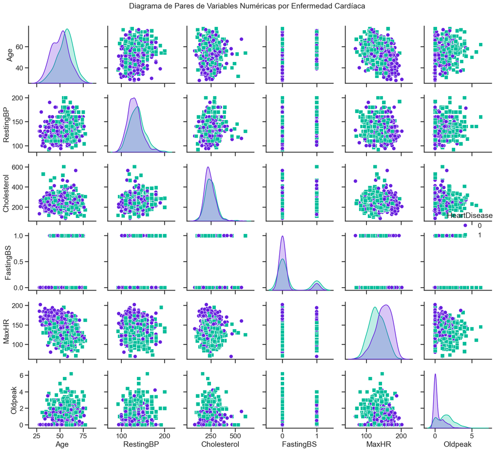

```python
color = ['#671FDD','#00BD9A']
sns.set(style="ticks")
sns.set_context("talk")
pairplot = sns.pairplot(data=df[num_data], hue='HeartDisease', palette=color,markers=['o','s'])
plt.subplots_adjust(top=1)
pairplot.fig.suptitle("Diagrama de Pares de Variables Numéricas por Enfermedad Cardíaca", fontsize=18,y=1)
plt.tight_layout()
plt.show()
```

### Procesamiento de datos

Para este ejercicio los varios datos categoricos como tipos de dolor en el pecho y sexo son variables directamente relacionados con las CVDs, por lo tanto se deben incluir en el entrenamiento, para esto hemos usado el metodo `get_dummies` de pandas para generar valores de dicotomicos a variables categoricas.

```python
df_processed = pd.get_dummies(df,drop_first = True)
df_processed.head()
```

|  | Age | RestingBP | Cholesterol | FastingBS | MaxHR | Oldpeak | HeartDisease | Sex_M | ChestPainType_ATA | ChestPainType_NAP | ChestPainType_TA | RestingECG_Normal | RestingECG_ST | ExerciseAngina_Y | ST_Slope_Flat | ST_Slope_Up |
| --- | --- | --- | --- | --- | --- | --- | --- | --- | --- | --- | --- | --- | --- | --- | --- | --- |
| 0 | 40 | 140 | 289 | 0 | 172 | 0.0 | 0 | True | True | False | False | True | False | False | False | True |
| 1 | 49 | 160 | 180 | 0 | 156 | 1.0 | 1 | False | False | True | False | True | False | False | True | False |
| 2 | 37 | 130 | 283 | 0 | 98 | 0.0 | 0 | True | True | False | False | False | True | False | False | True |
| 3 | 48 | 138 | 214 | 0 | 108 | 1.5 | 1 | False | False | False | False | True | False | True | True | False |
| 4 | 54 | 150 | 195 | 0 | 122 | 0.0 | 0 | True | False | True | False | True | False | False | False | True |

```python
# Dividimos los datos en variables independientes X, y variable dependiente y (especies)
x = df_processed.drop(['HeartDisease'],axis=1)
y = df_processed['HeartDisease']
```

```python
# Dividimos datos para entrenamiento y prueba
X_train, X_test, y_train, y_test = train_test_split(x, y, test_size=0.3)
```

```python
# Especificamos nuestro modelo
logisticRegr = LogisticRegression(max_iter = 1000)
```

```python
#Entrenamos el modelo
logisticRegr.fit(X_train, y_train)
```

```
LogisticRegression(max_iter=1000)
```

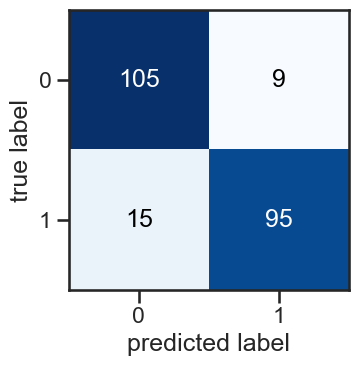

```python
# Revisamos la matriz de confusión para el modelo
ypred = logisticRegr.predict(X_test)
matriz = confusion_matrix(y_test,ypred)

plot_confusion_matrix(conf_mat=matriz, figsize=(4,4), show_normed=False)
plt.tight_layout()
```

```python
# Métricas del modelo
log_train_accuracy = round(logisticRegr.score(X_train, y_train) * 100, 2)
log_accuracy = round(accuracy_score(ypred, y_test) * 100, 2)
log_f1_score = round(f1_score(ypred, y_test) * 100, 2)

print("Precisión del Entrenamiento      :",log_train_accuracy,"%")
print("Precisión del Modelo             :",log_accuracy,"%")
print("Reporte de Clasificación         : \n",classification_report(y_test,ypred))
```

```
Precisión del Entrenamiento      : 85.82 %
Precisión del Modelo             : 89.29 %
Reporte de Clasificación         :
               precision    recall  f1-score   support

           0       0.88      0.92      0.90       114
           1       0.91      0.86      0.89       110

    accuracy                           0.89       224
   macro avg       0.89      0.89      0.89       224
weighted avg       0.89      0.89      0.89       224
```